# Factors that affecting housing price in the Saratoga County, New York.

C.O.Lam

June 2021

```r
library(easypackages)
libraries("tidyverse", "VIM", "skimr", "mosaicData", "ggpubr")
```

```
## VIM is ready to use.
```

```
## Suggestions and bug-reports can be submitted at: https://github.com/statistikat/VIM/issues
```

```
## All packages loaded successfully
```

```r
data("SaratogaHouses")
attach(SaratogaHouses)

options(scipen = 999)
```

### Data Preparation

Checking Data

```r
chk = is.na(SaratogaHouses)
table(chk)
```

```
## chk
## FALSE
## 27648
```

Apparently, there is no Null in the data set.

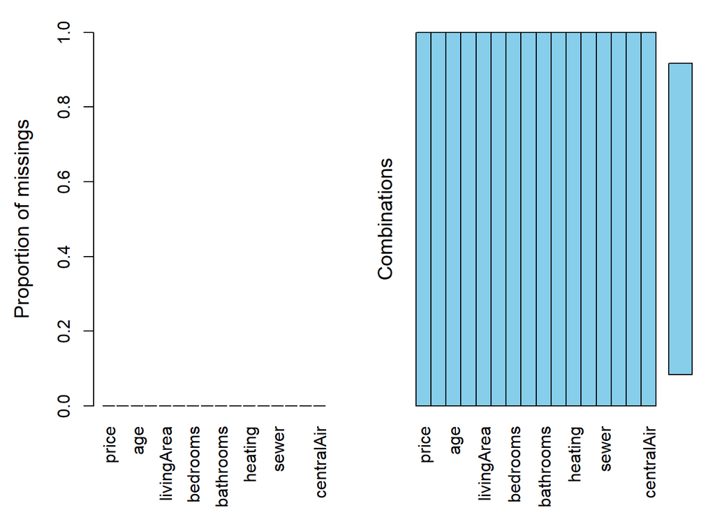

```
##
##  Variables sorted by number of missings:
##         Variable Count
##            price     0
##          lotSize     0
##              age     0
##        landValue     0
##       livingArea     0
##       pctCollege     0
##         bedrooms     0
##       fireplaces     0
##        bathrooms     0
##            rooms     0
##          heating     0
##             fuel     0
##            sewer     0
##       waterfront     0
##  newConstruction     0
##       centralAir     0
```

```r
missing_visual<-summary(aggr(SaratogaHouses, sortVar=TRUE))$combinations
```

There is no missing data in the data set. Other data issue?

```r
  str(SaratogaHouses)
```

```
## 'data.frame':    1728 obs. of  16 variables:
##  $ price          : int  132500 181115 109000 155000 86060 120000 153000 170000 90000 122900 ...
##  $ lotSize        : num  0.09 0.92 0.19 0.41 0.11 0.68 0.4 1.21 0.83 1.94 ...
##  $ age            : int  42 0 133 13 0 31 33 23 36 4 ...
##  $ landValue      : int  50000 22300 7300 18700 15000 14000 23300 14600 22200 21200 ...
##  $ livingArea     : int  906 1953 1944 1944 840 1152 2752 1662 1632 1416 ...
##  $ pctCollege     : int  35 51 51 51 51 22 51 35 51 44 ...
##  $ bedrooms       : int  2 3 4 3 2 4 4 4 3 3 ...
##  $ fireplaces     : int  1 0 1 1 0 1 1 1 0 0 ...
##  $ bathrooms      : num  1 2.5 1 1.5 1 1 1.5 1.5 1.5 1.5 ...
##  $ rooms          : int  5 6 8 5 3 8 8 9 8 6 ...
##  $ heating        : Factor w/ 3 levels "hot air","hot water/steam",..: 3 2 2 1 1 1 2 1 3 1 ...
##  $ fuel           : Factor w/ 3 levels "gas","electric",..: 2 1 1 1 1 1 3 3 2 1 ...
##  $ sewer          : Factor w/ 3 levels "septic","public/commercial",..: 1 1 2 1 2 1 1 1 1 3 ...
##  $ waterfront     : Factor w/ 2 levels "Yes","No": 2 2 2 2 2 2 2 2 2 2 ...
##  $ newConstruction: Factor w/ 2 levels "Yes","No": 2 2 2 2 1 2 2 2 2 2 ...
##  $ centralAir     : Factor w/ 2 levels "Yes","No": 2 2 2 2 1 2 2 2 2 2 ...
```

Each variable has the correct data type

### DEA

```r
  summary (SaratogaHouses[1])
```

```
##      price
##  Min.   :  5000
##  1st Qu.:145000
##  Median :189900
##  Mean   :211967
##  3rd Qu.:259000
##  Max.   :775000
```

```r
  skim (SaratogaHouses)
```

Data summary

| Name | SaratogaHouses |
| --- | --- |
| Number of rows | 1728 |
| Number of columns | 16 |
| _______________________ |  |
| Column type frequency: |  |
| factor | 6 |
| numeric | 10 |
| ________________________ |  |
| Group variables | None |

**Variable type: factor**

| skim_variable | n_missing | complete_rate | ordered | n_unique | top_counts |
| --- | --- | --- | --- | --- | --- |
| heating | 0 | 1 | FALSE | 3 | hot: 1121, ele: 305, hot: 302 |
| fuel | 0 | 1 | FALSE | 3 | gas: 1197, ele: 315, oil: 216 |
| sewer | 0 | 1 | FALSE | 3 | pub: 1213, sep: 503, non: 12 |
| waterfront | 0 | 1 | FALSE | 2 | No: 1713, Yes: 15 |
| newConstruction | 0 | 1 | FALSE | 2 | No: 1647, Yes: 81 |
| centralAir | 0 | 1 | FALSE | 2 | No: 1093, Yes: 635 |

**Variable type: numeric**

| skim_variable | n_missing | complete_rate | mean | sd | p0 | p25 | p50 | p75 | p100 | hist |
| --- | --- | --- | --- | --- | --- | --- | --- | --- | --- | --- |
| price | 0 | 1 | 211966.71 | 98441.39 | 5000 | 145000.00 | 189900.00 | 259000.00 | 775000.0 | ▅▇▂▁▁ |
| lotSize | 0 | 1 | 0.50 | 0.70 | 0 | 0.17 | 0.37 | 0.54 | 12.2 | ▇▁▁▁▁ |
| age | 0 | 1 | 27.92 | 29.21 | 0 | 13.00 | 19.00 | 34.00 | 225.0 | ▇▁▁▁▁ |
| landValue | 0 | 1 | 34557.19 | 35021.17 | 200 | 15100.00 | 25000.00 | 40200.00 | 412600.0 | ▇▁▁▁▁ |
| livingArea | 0 | 1 | 1754.98 | 619.94 | 616 | 1300.00 | 1634.50 | 2137.75 | 5228.0 | ▇▇▂▁▁ |
| pctCollege | 0 | 1 | 55.57 | 10.33 | 20 | 52.00 | 57.00 | 64.00 | 82.0 | ▁▃▆▇▁ |
| bedrooms | 0 | 1 | 3.15 | 0.82 | 1 | 3.00 | 3.00 | 4.00 | 7.0 | ▃▇▅▁▁ |
| fireplaces | 0 | 1 | 0.60 | 0.56 | 0 | 0.00 | 1.00 | 1.00 | 4.0 | ▆▇▁▁▁ |
| bathrooms | 0 | 1 | 1.90 | 0.66 | 0 | 1.50 | 2.00 | 2.50 | 4.5 | ▁▇▇▁▁ |
| rooms | 0 | 1 | 7.04 | 2.32 | 2 | 5.00 | 7.00 | 8.25 | 12.0 | ▃▇▇▅▂ |

There are 16 variables and 1728 observations in the data set. The data set contains 3 types of data: 6 variables are factors, 2 are numerics, and the rest are integer. In this data set, price is likely be the dependable variable. In the Saratoga County, New York, the minimum house price is $5000 and the maximum is $775000.  
On average, the house price is $211967, and the median housing price is $189900.

Next, we will look at the histogram. Here, we will use the Sturges method to find out the “breaks”. From the breaks, we will know the number of bin and the binwidth.

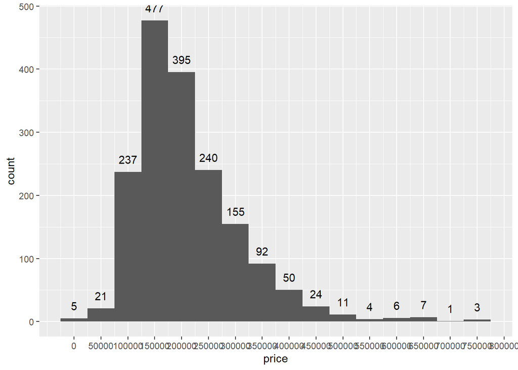

```r
  breaks <- pretty(range(SaratogaHouses$price),
                   n = nclass.Sturges(SaratogaHouses$price),
                   min.n = 1)

  ggplot(SaratogaHouses, aes(x=price)) +
     geom_histogram(binwidth = 50000,  boundary =25000)+
     stat_bin(binwidth = 50000, geom="text", aes(label=..count..) ,
              vjust = -1) +
     scale_x_continuous(breaks=c(0, 50000, 100000, 150000, 200000, 250000, 300000,
                                 350000, 400000, 450000, 500000, 550000, 600000,
                                 650000,700000, 750000, 800000),
                        labels = c("0", "50000", "100000", "150000", "200000", "250000", "300000",
                                   "350000", "400000", "450000", "500000", "550000", "600000",
                                   "650000", "700000", "750000", "800000") )
```

The distribution of price is right-skewed. Most housing prices are within $100k to $250k. The most common housing price is around $150k with 477 houses within that price range.

### The impact of fuel type on the price

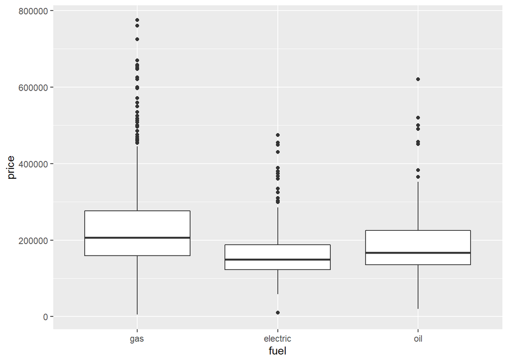

```r
  ggplot(SaratogaHouses, aes(x= fuel, y=price))+
    geom_boxplot( )
```

Overall, the three boxplots shares some similarities. For instance, they are slightly skewed to the right (positively skewed) based on the position of the median within the interquartile range (the box). They all have a lot of outliers beyond the top whisker.

From the plots, it seems that the median housing prices are different among the three fuel type groups. The median house price within the gas group (the first boxplot on the left) seems to be the highest among the three, followed by oil group (boxplot on the right) and electric group (boxplot in the middle). Nevertheless, an ANOVA is needed to determine if the difference exists.

```r
AOV1 <- aov(price ~ fuel, data = SaratogaHouses)
summary(AOV1)
```

```
##               Df         Sum Sq      Mean Sq F value              Pr(>F)
## fuel           2  1141871996720 570935998360   63.16 <0.0000000000000002 ***
## Residuals   1725 15593979795405   9039988287
## ---
## Signif. codes:  0 '***' 0.001 '**' 0.01 '*' 0.05 '.' 0.1 ' ' 1
```

The null hypothesis in an Anova states that there is no significant difference among the group means. In the SaratogaHouses case, Ho means the three fuel types will have the same impact on house prices.

From the AOV1 summary, the p-value for fuel is <0.0000000000000002 which is significantly smaller than the critical value of 0.05 (alpha). Therefore, we will reject the null hypothesis (there is no difference among the group means).  
We will accept the alternative hypothesis that there is a difference at least among two group means in terms of their impacts on house price.

Since fuel type has a significantly impact on the housing price in Saratoga, we may want to find out which fuel type(s) has impact on housing price.

```r
SaratogaHouses %>% group_by(fuel) %>% summarise(mean(price))
```

```
## # A tibble: 3 x 2
##   fuel     `mean(price)`
##   <fct>            <dbl>
## 1 gas            228535.
## 2 electric       164938.
## 3 oil            188734.
```

```r
pairwise.t.test(x=SaratogaHouses$price, g=SaratogaHouses$fuel, p.adj="bonf")
```

```
##
##  Pairwise comparisons using t tests with pooled SD
##
## data:  SaratogaHouses$price and SaratogaHouses$fuel
##
##          gas                  electric
## electric < 0.0000000000000002 -
## oil      0.000000052          0.014
##
## P value adjustment method: bonferroni
```

The mean housing prices of gas, electric, and oil are $228535, $164938, $188734 respectively. The results show that there is statistically significant difference between gas and electric, gas and oil, and electric and oil.

### Waterfront location and housing price

Another feature that might have impact on housing price is waterfront location. Make a box plot of price by waterfront type using boxplot()

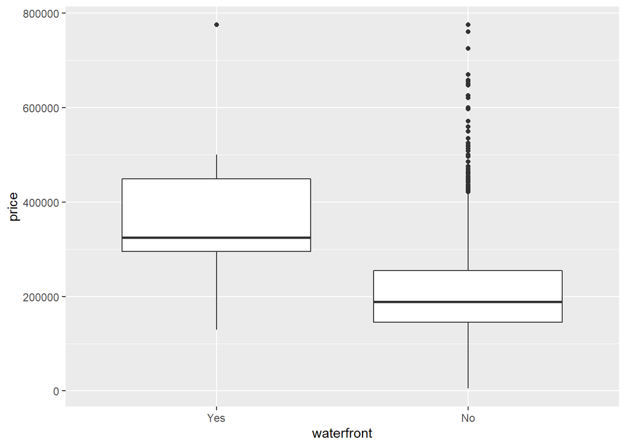

```r
ggplot(SaratogaHouses, aes(x=waterfront, y=price))+
  geom_boxplot()
```

The two boxplots do not look the same. The boxplot of the Yes (Waterfront location) group is clearly right-skewed with one outlier beyond the upper whisker. Its median housing price is higher than the No waterfront location group. However, there are lots of price variation on the high end among the houses within the no waterfront group. To find out the impact of waterfront location on housing price, we will first do a t-test, and then we will use an ANOVA.

### Assumptions of Normality and Equal Variance

In a t-test, the null hypothesis states that there is no difference among the means. In other words, Group A and Group B have no difference.

```r
PWithWater <- SaratogaHouses$price[SaratogaHouses$waterfront== "Yes"]
PWoutWater <-SaratogaHouses$price[SaratogaHouses$waterfront=="No"]

length(PWithWater)
```

```
## [1] 15
```

```r
length(PWoutWater)
```

```
## [1] 1713
```

There are only 15 houses with waterfront location. But there are 1713 houses without waterfront location. Using PWithWater and PWoutWater, perfrom a t-test using t.test()

```r
ttest <- t.test(PWithWater, PWoutWater)
```

**Test of Normality**

```r
W_Y <- SaratogaHouses %>% filter ( waterfront =="Yes")
W_N <-  SaratogaHouses %>% filter ( waterfront =="No")
```

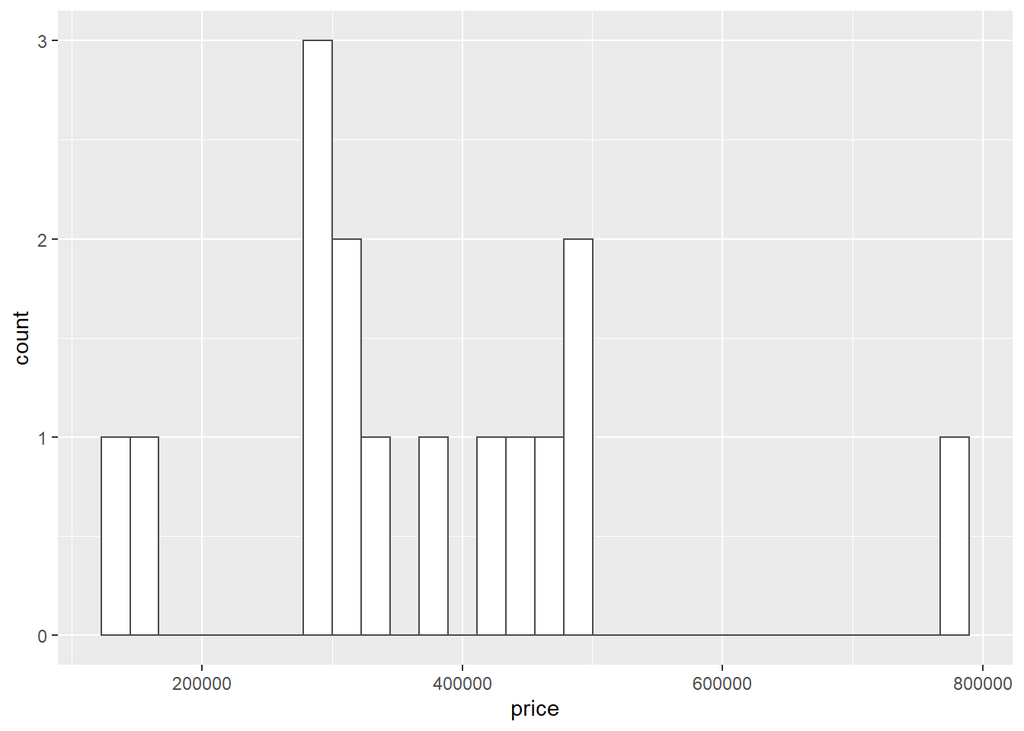

```r
ggplot(W_Y, aes(price)) +
  geom_histogram(fill = "white", color = "grey30")
```

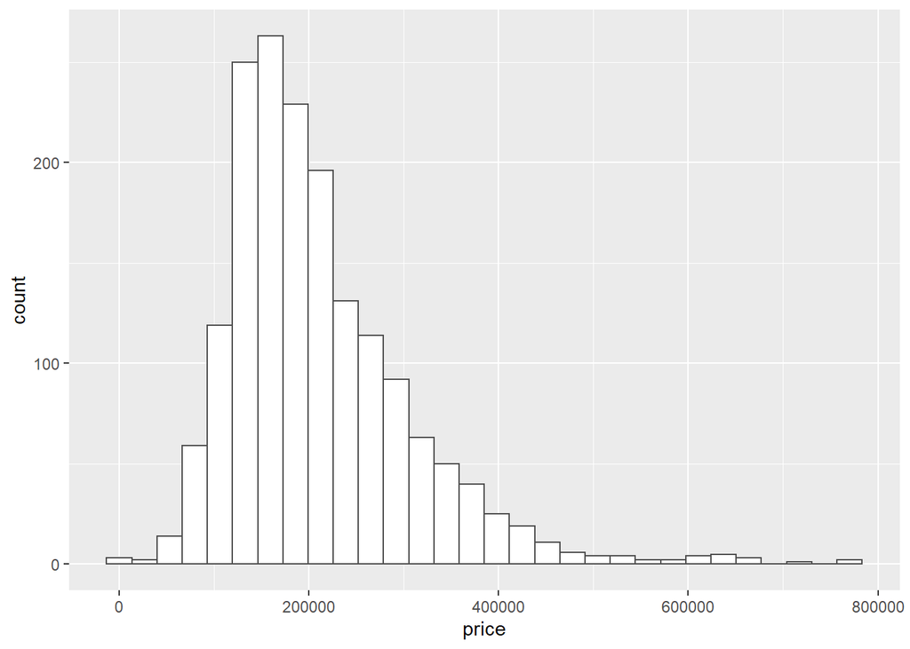

```r
ggplot(W_N, aes(price)) +
  geom_histogram(fill = "white", color = "grey30")
```

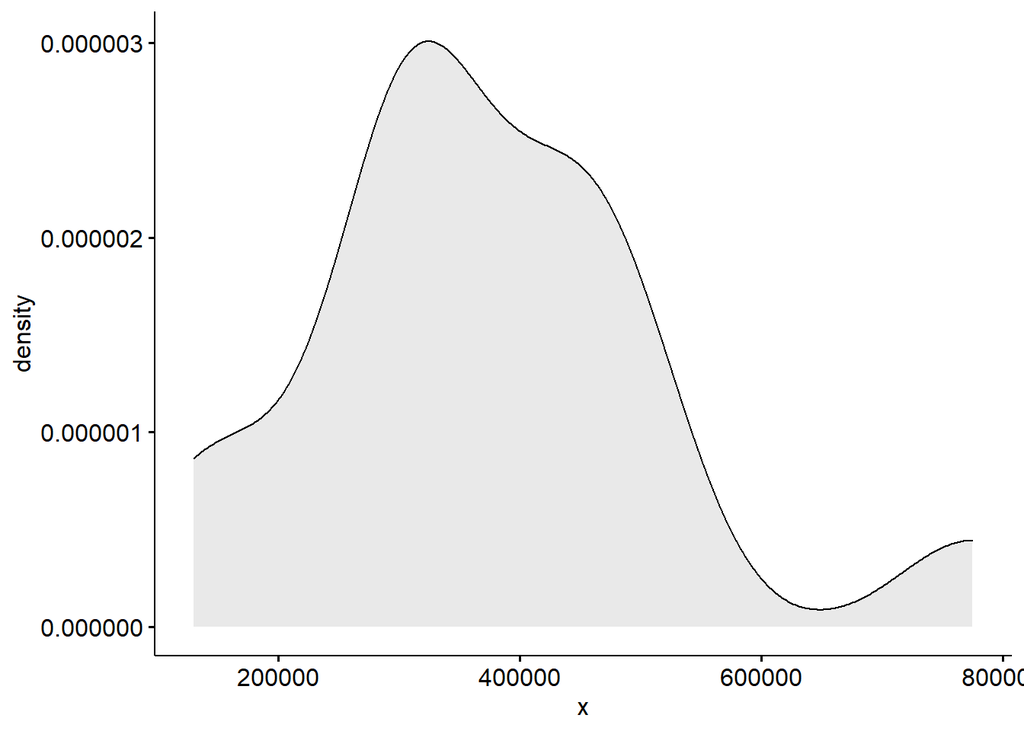

```r
ggdensity(W_Y$price, fill = "lightgray")
```

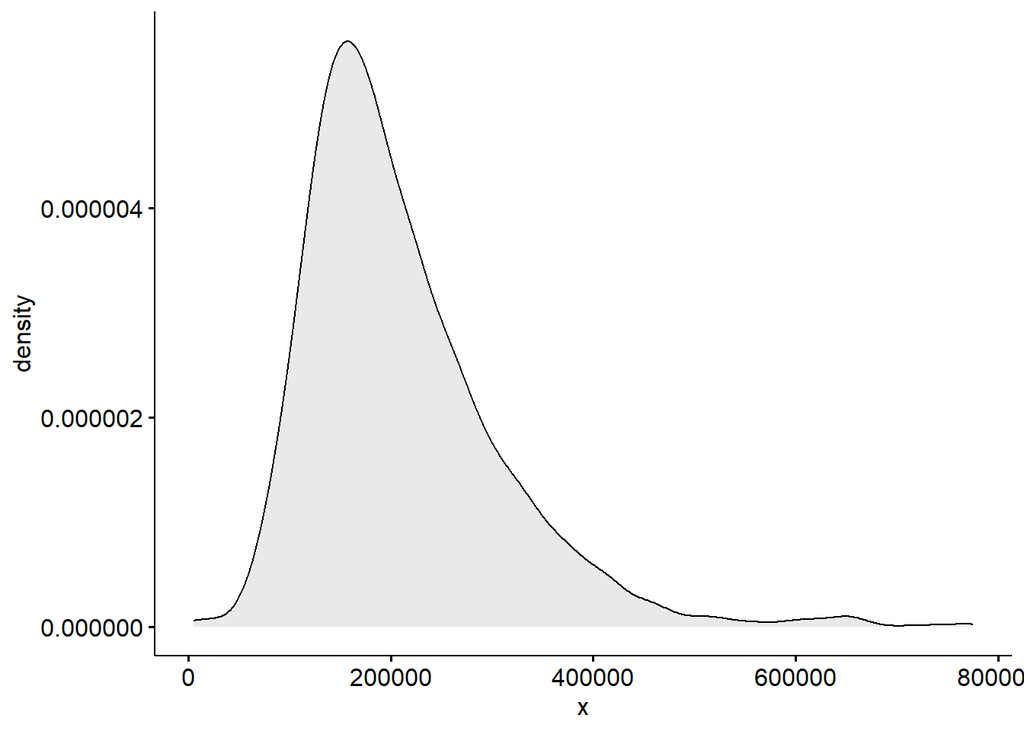

```r
ggdensity(W_N$price, fill = "lightgray")
```

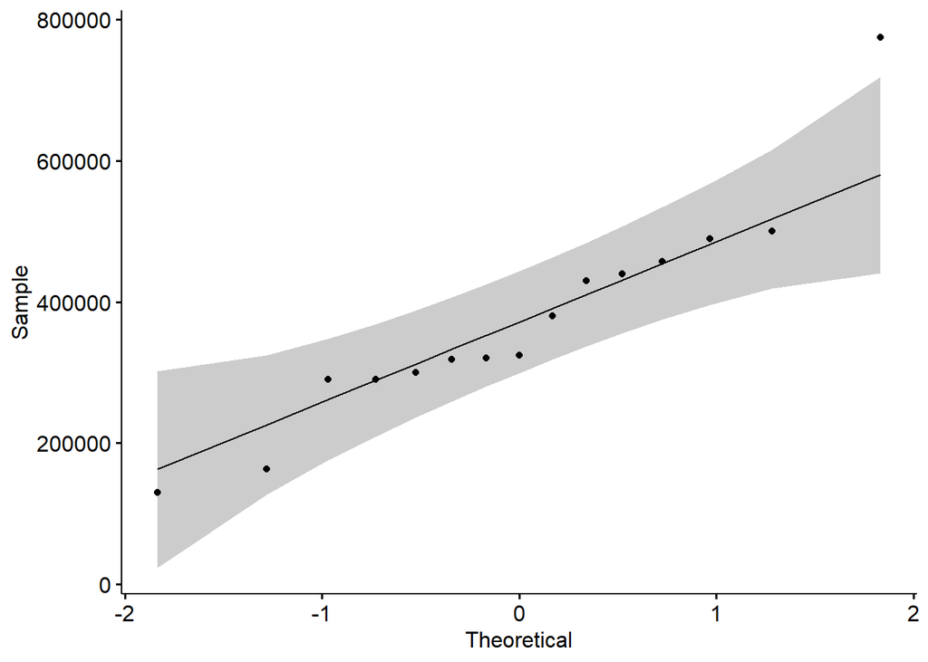

```r
ggqqplot(W_Y$price)
```

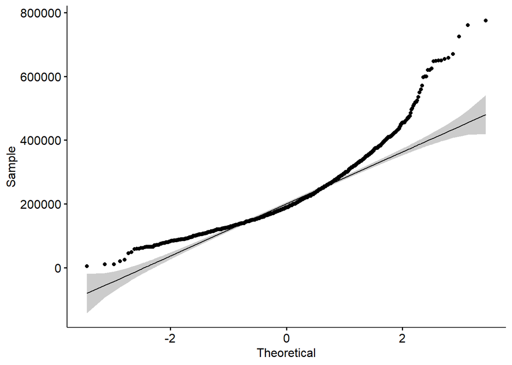

```r
ggqqplot(W_N$price)
```

The non-waterfront group clearly violates the normality assumption.

**Test of Equal Variance**

If the variances of the two groups of data are equal, the ratio will be 1, and vice versa. In the var test, the null hypothesis is that the variances are equal.

```r
var(PWithWater) / var(PWoutWater)
```

```
## [1] 2.571545
```

```r
var.test(PWithWater, PWoutWater)
```

```
##
##  F test to compare two variances
##
## data:  PWithWater and PWoutWater
## F = 2.5715, num df = 14, denom df = 1712, p-value = 0.002272
## alternative hypothesis: true ratio of variances is not equal to 1
## 95 percent confidence interval:
##  1.372705 6.407937
## sample estimates:
## ratio of variances
##           2.571545
```

The ratio is 2.57 and the p-value from the var.test. That means the null hypothesis of equal variances is rejected.

In summary, the 2 groups of data violates the normality and equal variance assumptions. Therefore, we have to use the non-parametric Wilcox test.

**Wilcox Test**

```r
wilcox.test(price ~ waterfront, data= SaratogaHouses )
```

```
##
##  Wilcoxon rank sum test with continuity correction
##
## data:  price by waterfront
## W = 21454, p-value = 0.000007731
## alternative hypothesis: true location shift is not equal to 0
```

```r
AOV2 <- aov(price ~ waterfront, data = SaratogaHouses)
summary(AOV2)
```

```
##               Df         Sum Sq      Mean Sq F value         Pr(>F)
## waterfront     1   397229493596 397229493596   41.96 0.000000000121 ***
## Residuals   1726 16338622298529   9466177461
## ---
## Signif. codes:  0 '***' 0.001 '**' 0.01 '*' 0.05 '.' 0.1 ' ' 1
```

The p-value is 0.000000000121 which is significantly smaller than the critical value of 0.05 (alpha). It suggests that there is a statistically significant difference at least among two group means in terms of their impacts on house price. In summary, a house with waterfront has a significantly impact on the price of house in Saratoga.

```r
SaratogaHouses %>% group_by(waterfront) %>% summarise(mean(price))
```

```
## # A tibble: 2 x 2
##   waterfront `mean(price)`
##   <fct>              <dbl>
## 1 Yes              373992.
## 2 No               210548.
```

The mean housing price of waterfront location is $373992 whereas the mean housing price of non-waterfront location is $210548

Since there is only 2 groups within the waterfront, it is reasonable to say that there is a statistically significant difference between the two groups.

### Will the fuel type and waterfront location affect housing price even more?

```r
AVO3 <- aov(price ~ waterfront + fuel, data = SaratogaHouses)
summary(AVO3)
```

```
##               Df         Sum Sq      Mean Sq F value               Pr(>F)
## waterfront     1   397229493596 397229493596   45.30      0.0000000000229 ***
## fuel           2  1222043555133 611021777566   69.69 < 0.0000000000000002 ***
## Residuals   1724 15116578743396   8768317137
## ---
## Signif. codes:  0 '***' 0.001 '**' 0.01 '*' 0.05 '.' 0.1 ' ' 1
```

The p-value of waterfront is 0.0000000000229, which is significantly smaller than the critical value of 0.05 (alpha). In other words, waterfront will affect housing price in Saratoga.  
The p-value of fuel type is < 0.0000000000000002, which is significantly smaller than the critical value of 0.05 (alpha). In other words, fuel type will affect housing price in Saratoga. Will there be an interaction effect?

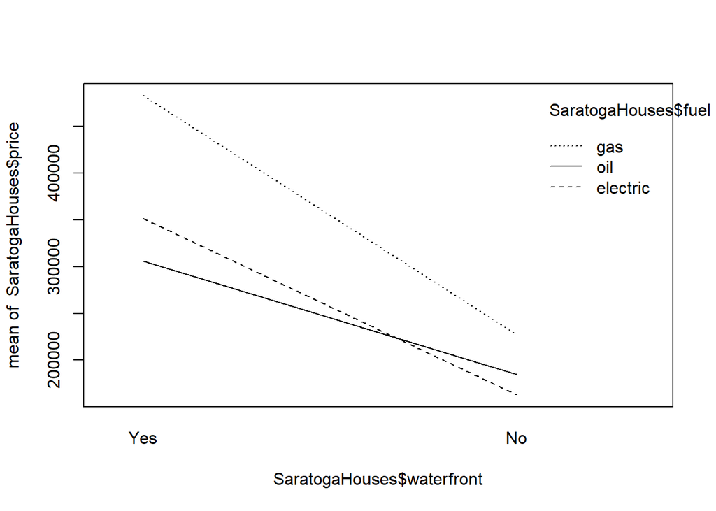

```r
interaction.plot(SaratogaHouses$waterfront,SaratogaHouses$fuel,SaratogaHouses$price)
```

The interaction plot shows that the oil line and the electric line cross each other. It seems to suggest that there is an interaction effect. Is it really the case?

```r
AVO4 <- aov(price ~ waterfront * fuel, data = SaratogaHouses)
summary(AVO4)
```

```
##                   Df         Sum Sq      Mean Sq F value               Pr(>F)
## waterfront         1   397229493596 397229493596  45.407      0.0000000000218
## fuel               2  1222043555133 611021777566  69.845 < 0.0000000000000002
## waterfront:fuel    2    52047336969  26023668484   2.975               0.0513
## Residuals       1722 15064531406428   8748276078
##
## waterfront      ***
## fuel            ***
## waterfront:fuel .
## Residuals
## ---
## Signif. codes:  0 '***' 0.001 '**' 0.01 '*' 0.05 '.' 0.1 ' ' 1
```

The results shows that the p-values for both waterfront and fuel type are very small (0.0000000000218 and < 0.0000000000000002 ). However, the p-value of the interaction effect is 0.0513. Since it is bigger than 0.05, it is not significant at the 0.05 significant level. In other words, there is no interaction effect on the housing price in Saratoga.